# Assignment3

Yerin Jung

6/8/2018

#########Set Up###########

```r
# Required libraries
library(tidyverse)
library(RcppRoll)
library(plotly)
library(ggpubr)
```

```r
# Setting up the data
setwd("/Users/Jung-yerin/Desktop/SUMMER_2018/AD/Week3")
ccard <-read_csv("res_purchase_card_(pcard)_fiscal_year_2014_3pcd-aiuu.csv")
```

```r
# Changing the column names
colnames(ccard)<-c('Year_Month', 'Agency_Number', 'Agency_Name', 'Cardholder_Last_Name',
      'Cardholder_First_Initial', 'Description', 'Amount', 'Vendor', 'Transaction_Date',
      'Posted_Date', 'Merchant_Category')
```

```r
# Filtering the Amount column
ccard <- ccard %>%filter(Amount>0)

# Changing `Transaction_Date` as Date
ccard <- ccard %>%
  mutate(Transaction_Date=as.Date(Transaction_Date,format="%m/%d/%Y %H:%M"))
```

First, I wanted to filter the values with the Amount less than 0 (Since we are interested in FRAUD detection.)  
Second, I changed `Transaction_Date` column into a Date format, for further analyses.

# 1 Aggregating by Time

## 1.1 Lead

In this section, I am going to examine the average/max amount of expenditure for a certain period of time.  
An agency is likely to have a consistent consumption pattern that does not deviate significantly from the average amount spent.  
When we detect irregular patterns or suddenly soaring amount of money, we might want to conduct further investigation.

## 1.2 EDA

Function to make rolling mean and max in XX weeks:

```r
Roll_MeanMax<- function(dataframe, nweeks){

  new_df <- dataframe %>%
    mutate(Weeks=strftime(Transaction_Date,format="%V"),
           new_col=( (as.numeric(Weeks)-1)%/% nweeks ) )%>%
    group_by(Agency_Name, new_col) %>%
    mutate(new_col_2=mean(Amount, na.rm = TRUE),
           new_col_3=max(Amount, na.rm = TRUE))%>%
    ungroup()

  names(new_df)[names(new_df) == 'new_col'] <-paste("Every",nweeks,"Wks",sep="_")
  names(new_df)[names(new_df) == 'new_col_2'] <-paste("RollMean",nweeks,"Wks",sep="_")
  names(new_df)[names(new_df) == 'new_col_3'] <-paste("RollMax",nweeks,"Wks",sep="_")

  return(new_df)
}
```

Function to make a rolling mean and rolling max plot:

```r
Roll_Plot <-function(dataframe, agency_name){

    avg_plot<- dataframe %>%
                filter(Agency_Name==agency_name) %>%
                ggplot(aes(x=Every_2_Wks, y=RollMean_2_Wks))+
                geom_point()+
                geom_line(color="red")+
                ggtitle(paste("Avg. Amount Spent Every 2Weeks by", agency_name, sep=" "))

    max_plot<- dataframe %>%
                filter(Agency_Name==agency_name) %>%
                ggplot(aes(x=Every_2_Wks, y=RollMax_2_Wks))+
                geom_point()+
                geom_line(color="blue")+
                ggtitle(paste("Max Amount Spent Every 2Weeks by", agency_name,sep=" "))
    ggarrange(avg_plot, max_plot, nrow = 2)
}
```

Applying functions:

```r
# Making a data frame with new columns
ccard_1 <-Roll_MeanMax(dataframe=ccard, nweeks=2)

# Examine the new columns
ccard_1 %>%
  select(Agency_Name, Every_2_Wks, RollMean_2_Wks, RollMax_2_Wks) %>%
  head(10)
```

```
## # A tibble: 10 x 4
##    Agency_Name               Every_2_Wks RollMean_2_Wks RollMax_2_Wks
##    <chr>                           <dbl>          <dbl>         <dbl>
##  1 OKLAHOMA STATE UNIVERSITY        15.0            307          5993
##  2 OKLAHOMA STATE UNIVERSITY        15.0            307          5993
##  3 OKLAHOMA STATE UNIVERSITY        15.0            307          5993
##  4 OKLAHOMA STATE UNIVERSITY        15.0            307          5993
##  5 OKLAHOMA STATE UNIVERSITY        15.0            307          5993
##  6 OKLAHOMA STATE UNIVERSITY        15.0            307          5993
##  7 OKLAHOMA STATE UNIVERSITY        15.0            307          5993
##  8 OKLAHOMA STATE UNIVERSITY        15.0            307          5993
##  9 OKLAHOMA STATE UNIVERSITY        15.0            307          5993
## 10 OKLAHOMA STATE UNIVERSITY        15.0            307          5993
```

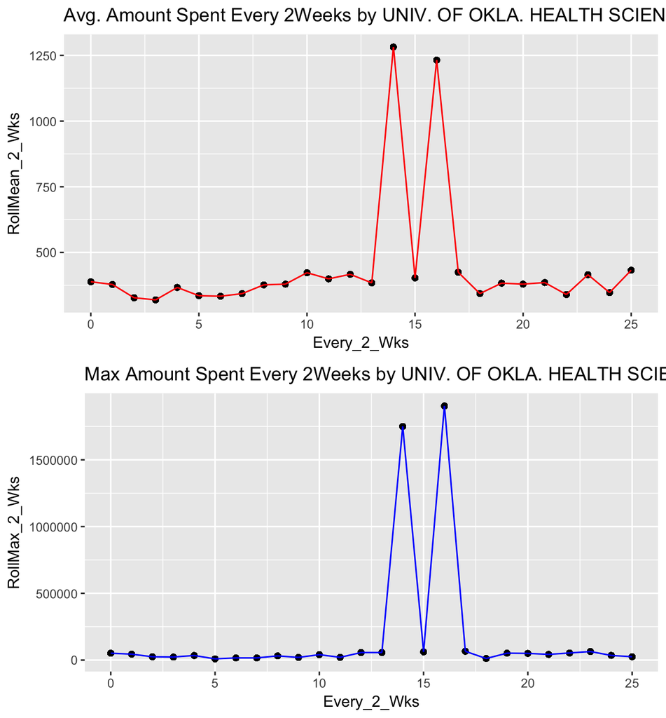

```r
# Plotting the results
Roll_Plot(ccard_1,"UNIV. OF OKLA. HEALTH SCIENCES CENTER")
```

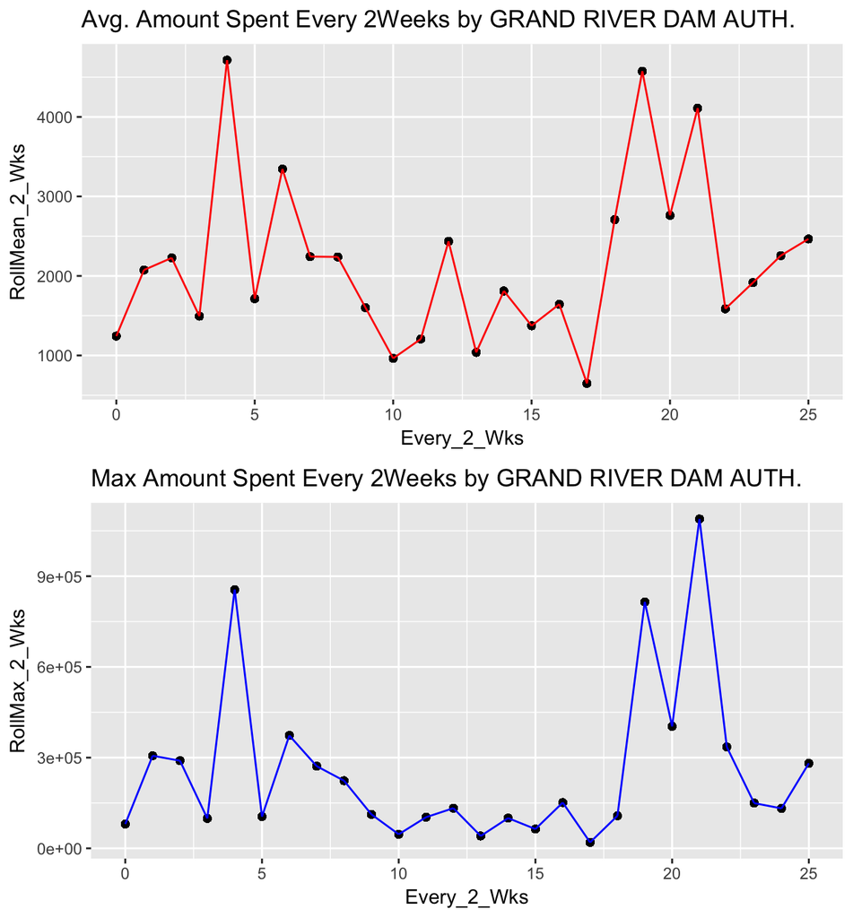

```r
Roll_Plot(ccard_1, "GRAND RIVER DAM AUTH.")
```

As we can see from the above two examples,  
there were some points that, all of sudden, the mean and max amount of expenditure of the agencies went through the roof.  
(2 points for “UNIV. OF OKLA. HEALTH SCIENCES CENTER”, and 3 points for “GRAND RIVER DAM AUTH.”)

## 1.3 Conclusion

When the maximum amount in every XX weeks soared, but the average amount in the same given period did not, it is possible that the agency just spent more money than other periods during that certain time.  
Therefore, when it comes to fraud detection, we may want to examine the period when both the $average$ and the $maximum$ spent in XX weeks soared together.

In addition, by comparing the average/maximum amount in one period with others, we can more easily detect the soared amount of the average/maximum spent, which is highly suspicious.

# 2 Aggregating by Merchant Categories

## 2.1 Lead

In this section, I am going to examine spending patterns of agencies by different merchants (`Merchant_Category`).  
One agency may spend across various merchant categories, or in just a few categories in a given time period.  
I believe that if we are able to find an expenditure that is from different merchant categories with what we believe as a ???normal??? ones, we might be able to detect a fraud.

## 2.2 EDA

First, I am going to make two new columns  
- `Merchant_Mth_Sum`: Summation of each `Merchant_Category` by `Month`  
- `Merchant_Mth_Per`: Percentage of the summation in every montly expenditure

```r
# Creating a data frame with new columns
ccard_2 <- ccard_1 %>%
  mutate(Month=strftime(Transaction_Date, format="%m")) %>%
  group_by(Agency_Name, Month, Merchant_Category) %>%
  mutate(Merchant_Mth_Sum=sum(Amount)) %>%
  ungroup() %>%
  group_by(Agency_Name, Month) %>%
  mutate(Merchant_Mth_Per = Merchant_Mth_Sum/sum(Amount)) %>%
  ungroup()
# Examining the new columns
ccard_2 %>%
  select(Agency_Name, Merchant_Category, Merchant_Mth_Sum, Merchant_Mth_Per) %>%
  head(10)
```

```
## # A tibble: 10 x 4
##    Agency_Name    Merchant_Category      Merchant_Mth_Sum Merchant_Mth_Per
##    <chr>          <chr>                             <dbl>            <dbl>
##  1 OKLAHOMA STAT~ CHARITABLE AND SOCIAL~            45045          0.0154
##  2 OKLAHOMA STAT~ SHERATON                           8864          0.00304
##  3 OKLAHOMA STAT~ DIRCT MARKETING/DIRCT~            73753          0.0253
##  4 OKLAHOMA STAT~ GROCERY STORES,AND SU~            33603          0.0115
##  5 OKLAHOMA STAT~ STATIONERY, OFFICE SU~            64887          0.0222
##  6 OKLAHOMA STAT~ OFFICE, PHOTOGRAPHIC,~            15837          0.00543
##  7 OKLAHOMA STAT~ GROCERY STORES,AND SU~            33603          0.0115
##  8 OKLAHOMA STAT~ FAST FOOD RESTAURANTS             15981          0.00548
##  9 OKLAHOMA STAT~ MENS, WOMENS AND CHIL~             5426          0.00186
## 10 OKLAHOMA STAT~ TELECOMMUNICATION SER~             8611          0.00295
```

Second, I am going to make a function to print the merchant categories that take more than XX% (which I can set) and plot the results.

```r
Merchant_Func<- function(dataframe, agency_name,filter_pct){

selected_df<- dataframe %>%
  filter(Agency_Name==agency_name) %>%
  filter(Merchant_Mth_Per>filter_pct)
selected_mer <- unique(selected_df$Merchant_Category)

print(paste("The merchant categories over ",filter_pct,"% are:",sep=""))
print(paste(selected_mer,collapse =", "))

dataframe %>%
  filter(Agency_Name==agency_name) %>%
  filter(Merchant_Mth_Per>filter_pct) %>%
  ggplot(aes(x=Merchant_Category, y=Merchant_Mth_Per, color=Merchant_Category))+
  geom_point()+
  facet_wrap(~Month)+
  ggtitle(agency_name)+
  theme(axis.title.x=element_blank(),
        axis.text.x=element_blank(),
        axis.ticks.x=element_blank())

}
```

The interesting results as follows:

```r
Merchant_Func(ccard_2, "OKLAHOMA STATE UNIVERSITY", 0.05)
```

```
## [1] "The merchant categories over 0.05% are:"
## [1] "DENTAL/LABORATORY/MEDICAL/OPHTHALMIC HOSP EQIP AND SUP., BUSINESS SERVICES NOT ELSEWHERE CLASSIFIED, MISCELLANEOUS AND SPECIALTY RETAIL STORES, INDUSTRIAL SUPPLIES NOT ELSEWHERE CLASSIFIED"
```

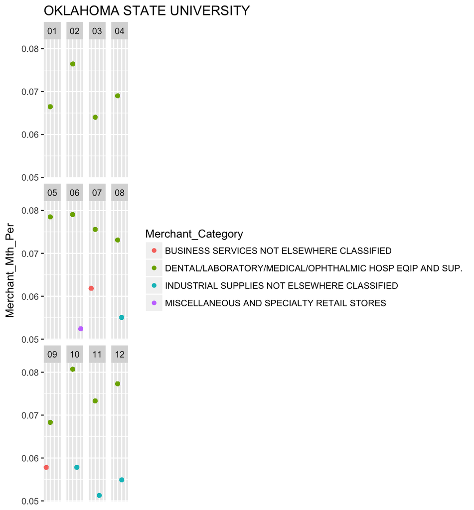

```r
Merchant_Func(ccard_2, "UNIV. OF OKLA. HEALTH SCIENCES CENTER", 0.15)
```

```
## [1] "The merchant categories over 0.15% are:"
## [1] "OTHER FEES, DENTAL/LABORATORY/MEDICAL/OPHTHALMIC HOSP EQIP AND SUP."
```

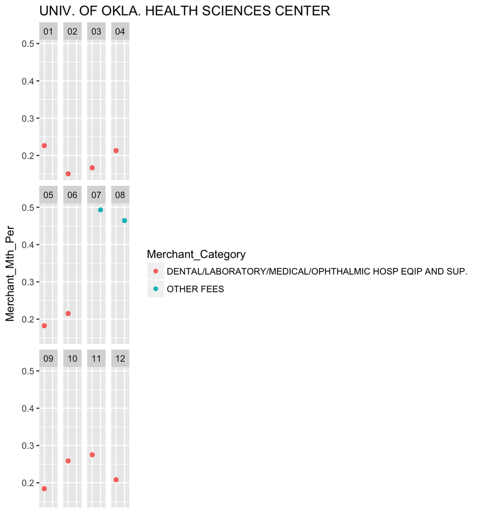

```r
Merchant_Func(ccard_2, "DEPARTMENT OF CORRECTIONS", 0.15)
```

```
## [1] "The merchant categories over 0.15% are:"
## [1] "INDUSTRIAL SUPPLIES NOT ELSEWHERE CLASSIFIED, CATALOG MERCHANTS"
```

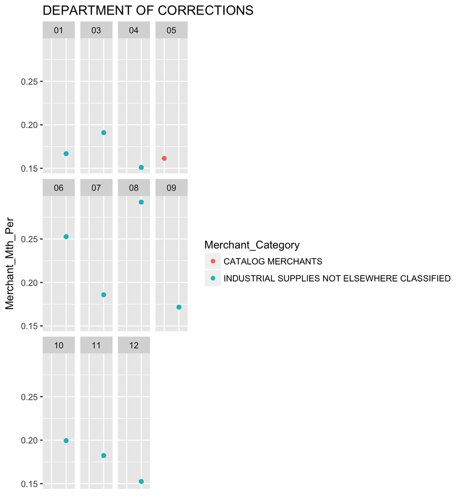

1. Pattern with various components (Various Pattern)
- As we can see from the first graph, “OKLAHOMA STATE UNIVERSITY” tend to spend across various merchant categories.  
  There was no such category that takes more than 10% of the monthly outlay.
2. Pattern with a few dominant components (Monotonous Pattern)
- On the other hand, “UNIV. OF OKLA. HEALTH SCIENCES CENTER” and “DEPARTMENT OF CORRECTIONS” tend to spend across only a few numbers of merchant categories.
- `"UNIV. OF OKLA. HEALTH SCIENCES CENTER"`:  
  As we can see from the second graph, in most of the months, they spent around 20% in `DENTAL/LABORATORY` category.  
  However, we can see that in July and August, they suddenly spent on `Other Fees` up to 50%. Since it happened for consecutive two months, we may not be able to simply assume that it is highly likely to be a fraud.  
  However, it still needs to be examined.
- `"DEPARTMENT OF CORRECTIONS"`:  
  In the third graph, we can see that they mostly spent on the `INDUSTRIAL SUPPLIES NOT ELSEWHERE CLASSIFIED` category.  
  However, in May, suddenly `CATALOG MERCHANTS` showed up and the dominant `Industrial Supplies` disappeared. As such, it may need further examination.

## 2.3 Conclusion

By using the features that I have used above, we could find three distinctive pattern changes.

1. Various Pattern to Monotonous One
- If the various consumption patterns become monotonous, we could suspect this as a fraud.
2. Variable Change in Monotonous Pattern
- If the components of a monotonous consumption pattern change, we could suspect this as a fraud.
- This is the case of “UNIV. OF OKLA. HEALTH SCIENCES CENTER” and “DEPARTMENT OF CORRECTIONS” above.
3. Variable Change in Various Pattern
- If the components that were evenly distributed turn into a combination of one or two dominant components, we could suspect this as a fraud.

# 3 Examining Using Frequency

## 3.1 Lead

When fraudsters try to commit fraud, first they would want to make sure whether transaction works. They probably check out a relatively small amount of money, and only if it works, would try bigger amount of money.

## 3.2 EDA

Finally, I am going to filter to find `Merchant_Mth_Per` less than 3%, since they can possibly be an abnormal expenditure.

```r
ccard_3 <- ccard_2 %>%
              arrange(Agency_Name,Transaction_Date) %>%
              mutate(Time_Diff = Transaction_Date-lag(Transaction_Date) ) %>%
              mutate( Time_Gap=ifelse((Time_Diff>10 & lag(Time_Diff)==0), 1, 0) )

ccard_3 %>%
  filter(Time_Gap==1) %>%
  filter(Merchant_Mth_Per<0.03) %>%
  select(Agency_Name, Merchant_Category, Vendor, Amount)
```

```
## # A tibble: 14 x 4
##    Agency_Name                       Merchant_Category     Vendor   Amount
##    <chr>                             <chr>                 <chr>     <dbl>
##  1 BD. OF EXAM. FOR LT CARE ADMIN.   GOVERNMENT SERVICES-~ NPDB N~   4.75
##  2 COMM. OF THE LAND OFFICE          TOLLS AND BRIDGE FEES PIKEPA~   0.160
##  3 DEPARTMENT OF EMERGENCY MANAGEMEN CHARITABLE AND SOCIA~ OKAPP    54.0
##  4 OFFICE OF DISABILITY CONCERNS     STATIONERY, OFFICE S~ STAPLES  58.0
##  5 OFFICE OF DISABILITY CONCERNS     STATIONERY, OFFICE S~ STAPLES  55.9
##  6 OK. SCHOOL OF SCIENCE & MATH.     STATIONERY,OFFICE AN~ FUZZEL~  97.0
##  7 OKLA. REAL ESTATE COMM.           DISCOUNT STORES       WALMAR~  56.7
##  8 OKLAHOMA LOTTERY COMMISSION       TRAVEL AGENCIES       JOURNY~  25.0
##  9 OKLAHOMA WHEAT COMMISSION         ARTIST SUPPLY AND CR~ MICHAE~   9.99
## 10 OKLAHOMA WHEAT COMMISSION         TELECOMMUNICATION SE~ AT&T B~  50.7
## 11 ST. BD. OF CHIROPRACTIC EXAM.     CHARITABLE AND SOCIA~ CLB IA~  12.0
## 12 ST. BD. OF CHIROPRACTIC EXAM.     DETECTIVE AGENCIES,P~ CSG NA~  34.0
## 13 STATE BANKING DEPARTMENT          NURSERIES,LAWN AND G~ CALVER~ 115
## 14 STATE PHARMACY BOARD              HARDWARE STORES       ABSUPP~  36.5
```

We can find the above 14 rows.

## 3.3 Conclusion

Although the amount of spending in these 14 rows might be small and the column itself may not be as much as efficient as the others, they may imply a starting point of certain fraud.  
By keeping the `Time_Diff` and `Time_Gap` column, we will be able to build a more accurate model in the next steps.